# TP2_Markov

```python
import sys
sys.path.append("/home/macbuse/miniconda3/lib/python3.11/site-packages")

import numpy as np
import numpy.random as npr
import matplotlib.pyplot as plt
import scipy.stats as stats
```

On considère la chaîne de Markov vue en TD dont l'espace des états est ${1,\ldots,6}$ et la matrice de transition est

$$\begin{pmatrix} 1 & 0 & 0 & 0 & 0 & 0 \\ \frac14 & \frac12 & \frac14 & 0 & 0 & 0 \\ 0 & \frac15 & \frac25 & \frac15 & 0 & \frac15 \\ 0 & 0 & 0 & \frac16 & \frac13 & \frac12 \\ 0 & 0 & 0 & \frac12 & 0 & \frac12 \\ 0 & 0 & 0 & \frac14 & 0 & \frac34 \end{pmatrix}.$$

On note (C = {4,5,6}). Dans toute la suite, on suppose que la chaîne part d’un état (x) fixé :

$$ \mathbb{P}(X_0 = x) = 1. $$

# Start by visualizing the chain

as a labelled graph

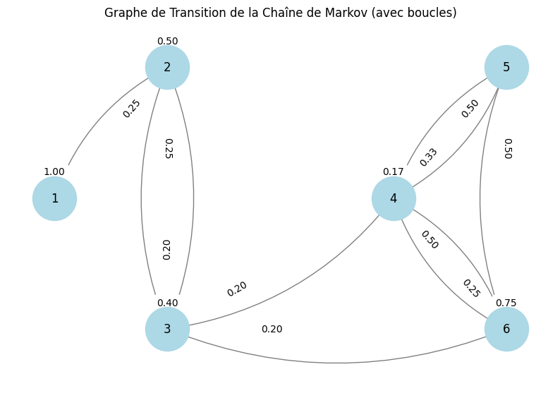

```python
# Matrice de transition
P = np.array([
    [1,    0,    0,    0,    0,    0],
    [1/4, 1/2, 1/4, 0,    0,    0],
    [0,   1/5, 2/5, 1/5, 0,   1/5],
    [0,   0,   0,   1/6, 1/3, 1/2],
    [0,   0,   0,   1/2, 0,   1/2],
    [0,   0,   0,   1/4, 0,   3/4]
])

# Utilisation de P.shape pour plus de flexibilité
nb_etats = P.shape[0]
etats = range(1, nb_etats + 1)

G = nx.DiGraph()
G.add_nodes_from(etats)

# Ajout des arêtes
for i in range(nb_etats):
    for j in range(nb_etats):
        if P[i, j] > 0:
            G.add_edge(i + 1, j + 1, weight=P[i, j], label=f"{P[i, j]:.2f}")

pos = {1: (0, 1), 2: (1, 2), 3: (1, 0), 4: (3, 1), 5: (4, 2), 6: (4, 0)}

fig, ax = plt.subplots(figsize=(10, 7))

# 1. Dessiner les nœuds
nx.draw_networkx_nodes(G, pos, ax=ax,
                       node_size=2000, node_color="lightblue")
nx.draw_networkx_labels(G, pos, ax=ax,
                        font_size=12)

# 2. Dessiner les arêtes avec une courbure pour rendre les boucles visibles
# 'arc3,rad=0.2' crée une courbe, permettant aux boucles de s'écarter du nœud
nx.draw_networkx_edges(
    G, pos, ax=ax,
    arrowstyle='->',
    arrowsize=20,
    connectionstyle='arc3,rad=0.2',
    edge_color="gray"
)

# 3. Dessiner les étiquettes des probabilités
edge_labels = nx.get_edge_attributes(G, "label")
# Note : la courbure peut décaler les labels, on ajuste l'affichage ici
nx.draw_networkx_edge_labels(G, pos, edge_labels=edge_labels, ax=ax,
                             font_size=10, label_pos=0.3)

ax.set_title("Graphe de Transition de la Chaîne de Markov (avec boucles)")
ax.axis("off")
plt.show()
```

## Analyse des Vecteurs Propres de la Matrice de Transition

La structure de la matrice $P$ est fondamentale pour comprendre ses vecteurs propres. Il s'agit d'une matrice stochastique par blocs, ce qui signifie que l'espace des états $\{1, \dots, 6\}$ est divisé en sous-ensembles aux comportements distincts : l'état absorbant (1), les états transitoires (2, 3), et la classe terminale (4, 5, 6).

### 1. Les Valeurs Propres ($\lambda$)

Pour toute matrice de transition, la plus grande valeur propre est toujours $\lambda = 1$. Dans votre cas :

- **$\lambda = 1$ est une valeur propre double** : Cela indique la présence de deux classes fermées (ensembles d'états dont on ne peut plus sortir). Ici, l'état $\{1\}$ et le bloc $C = \{4, 5, 6\}$.
- **$|\lambda| < 1$** : Les autres valeurs propres sont associées aux états transitoires. Elles déterminent la vitesse à laquelle la chaîne quitte les états 2 et 3 pour être absorbée par l'une des deux classes fermées.

### 2. Vecteurs Propres à Gauche (Mesures Invariantes)

Les vecteurs propres à gauche ($vP = \lambda v$) associés à $\lambda = 1$ représentent les distributions de probabilité stationnaires. Comme il y a deux classes fermées, il existe deux vecteurs de base linéairement indépendants :

#### A. Le point fixe de l'état 1

Si la chaîne commence ou tombe dans l'état 1, elle y reste indéfiniment. $$v_1 = (1, 0, 0, 0, 0, 0)$$

#### B. La loi stationnaire du bloc $C = \{4, 5, 6\}$

```python
from numba import jit
# doesn't work the p= option in choice isn't supported
# there are workarounds https://github.com/numba/numba/issues/2539
```

```python
def simuler_trajectoire(matrice, x_init, n=100):
    """
    Simule une trajectoire de chaîne de Markov sans utiliser append.

    matrice : np.array (la matrice de transition)
    x_init  : int (état initial de 1 à N)
    n       : int (nombre de sauts/transitions)
    """
    # 1. On récupère la dimension dynamiquement
    nb_etats = matrice.shape[0]
    indices_etats = np.arange(1, nb_etats + 1)

    # 2. Pré-allocation du tableau (taille n + 1 pour inclure l'état initial)
    trajectoire = np.zeros(n + 1, dtype=np.int32)
    trajectoire[0] = x_init

    # 3. Boucle de simulation
    for t in range(1, n + 1):
        # On utilise l'état précédent (t-1) pour calculer l'état actuel (t)
        trajectoire[t] = np.random.choice(
            indices_etats,
            p=matrice[trajectoire[t-1] - 1]
        )

    return trajectoire

# Exemple d'exécution
resultat = simuler_trajectoire(P, 6, n=100)
print(f"Trajectoire de {len(resultat)} points : {resultat}")
```

```
Trajectoire de 101 points : [6 6 6 6 6 6 6 6 4 4 4 6 6 6 6 4 5 6 6 6 6 6 6 6 4 6 4 6 6 6 4 6 6 4 5 4 5
 4 6 6 6 6 6 6 6 4 5 4 5 6 6 6 4 6 6 4 5 4 4 5 4 5 4 4 6 6 6 6 6 6 6 6 6 4
 5 6 6 6 6 6 4 6 6 6 6 6 4 6 6 6 4 4 5 4 5 4 5 4 6 4 6]
```

2. Lorsque $x \in C$, vérifier expérimentalement que la loi de $X_n$ converge lorsque $n \to +\infty$ vers la loi invariante $(\mu_4,\mu_5,\mu_6)$ de la chaîne restreinte à $C$ : on superposera la probabilité empirique (sur un échantillon de taille 1000) pour $X_n$ de prendre les valeurs 4, 5 ou 6 avec les valeurs de $(\mu_4,\mu_5,\mu_6)$. On effectuera ceci pour (n = 5), (n = 20), (n = 50).